# Exploring the Prosper Loan Dataset

## Preliminary Wrangling

I have chosen the Prosper Loan Dataset, which is a financial dataset of borrowers and the many points of data collected regarding things such as:

- risk assesments
- credit ratings
- interest rates
- income ranges etc.

In fact, there are 81 columns with different variables where I have to explore what might be relevant and useful to analyse.

The company Prosper is a peer-to-peer funded lending service, helping borrowers lend from other peers instead of traditional banking, more info about prosper can be found here: https://www.prosper.com/about

```python
# import all packages and set plots to be embedded inline
import numpy as np
import pandas as pd
import matplotlib.pyplot as plt
import seaborn as sns

%matplotlib inline
```

> Load in your dataset and describe its properties through the questions below. Try and motivate your exploration goals through this section.

```python
df = pd.read_csv('prosperLoanData.csv')
```

```python
df.sample(10)
```

|  | ListingKey | ListingNumber | ListingCreationDate | CreditGrade | Term | LoanStatus | ClosedDate | BorrowerAPR | BorrowerRate | LenderYield | ... | LP_ServiceFees | LP_CollectionFees | LP_GrossPrincipalLoss | LP_NetPrincipalLoss | LP_NonPrincipalRecoverypayments | PercentFunded | Recommendations | InvestmentFromFriendsCount | InvestmentFromFriendsAmount | Investors |
| --- | --- | --- | --- | --- | --- | --- | --- | --- | --- | --- | --- | --- | --- | --- | --- | --- | --- | --- | --- | --- | --- |
| 64953 | 5A023599496939423E6A3C8 | 1144800 | 2014-01-18 17:10:19.620000000 | NaN | 60 | Current | NaN | 0.15425 | 0.1314 | 0.1214 | ... | -14.86 | 0.0 | 0.00 | 0.00 | 0.0 | 1.0 | 0 | 0 | 0.0 | 1 |
| 27464 | 019E35543389562748B4CB8 | 620824 | 2012-08-05 09:42:18.500000000 | NaN | 36 | Completed | 2012-11-13 00:00:00 | 0.23939 | 0.2019 | 0.1919 | ... | -14.50 | 0.0 | 0.00 | 0.00 | 0.0 | 1.0 | 0 | 0 | 0.0 | 106 |
| 91262 | 714C35417143078595CE37A | 571177 | 2012-03-22 22:02:24.687000000 | NaN | 36 | Current | NaN | 0.35797 | 0.3177 | 0.3077 | ... | -28.92 | 0.0 | 0.00 | 0.00 | 0.0 | 1.0 | 0 | 0 | 0.0 | 46 |
| 74234 | E0B836045172675303B71EA | 1238841 | 2014-02-28 06:29:21.440000000 | NaN | 36 | Current | NaN | 0.11548 | 0.0874 | 0.0774 | ... | 0.00 | 0.0 | 0.00 | 0.00 | 0.0 | 1.0 | 0 | 0 | 0.0 | 1 |
| 34939 | 6BEC34831740614283C75F2 | 456270 | 2010-04-29 13:50:16.260000000 | NaN | 36 | Completed | 2013-04-10 00:00:00 | 0.07439 | 0.0710 | 0.0610 | ... | -52.71 | 0.0 | 0.00 | 0.00 | 0.0 | 1.0 | 1 | 0 | 0.0 | 192 |
| 59510 | 555B3589450117573687461 | 921109 | 2013-09-22 15:16:02.657000000 | NaN | 60 | Current | NaN | 0.30337 | 0.2769 | 0.2669 | ... | -12.39 | 0.0 | 0.00 | 0.00 | 0.0 | 1.0 | 0 | 0 | 0.0 | 3 |
| 25924 | C619359658123585796FD98 | 1038103 | 2013-12-09 07:20:02.967000000 | NaN | 60 | Current | NaN | 0.23984 | 0.2150 | 0.2050 | ... | -16.91 | 0.0 | 0.00 | 0.00 | 0.0 | 1.0 | 0 | 0 | 0.0 | 1 |
| 26437 | 9EEC3402275559246C22C3C | 215913 | 2007-10-14 19:27:24.680000000 | D | 36 | Defaulted | 2009-02-23 00:00:00 | 0.17722 | 0.1700 | 0.1600 | ... | -36.78 | 0.0 | 3360.46 | 3360.47 | 0.0 | 1.0 | 1 | 0 | 0.0 | 164 |
| 50139 | 42063417024702162D265DC | 307488 | 2008-04-10 18:39:32.260000000 | B | 36 | Completed | 2011-04-15 00:00:00 | 0.15629 | 0.1420 | 0.1320 | ... | -49.74 | 0.0 | 0.00 | 0.00 | 0.0 | 1.0 | 0 | 0 | 0.0 | 62 |
| 29230 | BEDD3601752910463758B5C | 1172943 | 2014-01-30 14:11:21.660000000 | NaN | 36 | Current | NaN | 0.14714 | 0.1189 | 0.1089 | ... | -3.84 | 0.0 | 0.00 | 0.00 | 0.0 | 1.0 | 0 | 0 | 0.0 | 1 |

10 rows × 81 columns

```python
df.info()
```

```
<class 'pandas.core.frame.DataFrame'>
RangeIndex: 113937 entries, 0 to 113936
Data columns (total 81 columns):
 #   Column                               Non-Null Count   Dtype
---  ------                               --------------   -----
 0   ListingKey                           113937 non-null  object
 1   ListingNumber                        113937 non-null  int64
 2   ListingCreationDate                  113937 non-null  object
 3   CreditGrade                          28953 non-null   object
 4   Term                                 113937 non-null  int64
 5   LoanStatus                           113937 non-null  object
 6   ClosedDate                           55089 non-null   object
 7   BorrowerAPR                          113912 non-null  float64
 8   BorrowerRate                         113937 non-null  float64
 9   LenderYield                          113937 non-null  float64
```

[output cut: 73 more lines]

```python
df.describe()
```

|  | ListingNumber | Term | BorrowerAPR | BorrowerRate | LenderYield | EstimatedEffectiveYield | EstimatedLoss | EstimatedReturn | ProsperRating (numeric) | ProsperScore | ... | LP_ServiceFees | LP_CollectionFees | LP_GrossPrincipalLoss | LP_NetPrincipalLoss | LP_NonPrincipalRecoverypayments | PercentFunded | Recommendations | InvestmentFromFriendsCount | InvestmentFromFriendsAmount | Investors |
| --- | --- | --- | --- | --- | --- | --- | --- | --- | --- | --- | --- | --- | --- | --- | --- | --- | --- | --- | --- | --- | --- |
| count | 1.139370e+05 | 113937.000000 | 113912.000000 | 113937.000000 | 113937.000000 | 84853.000000 | 84853.000000 | 84853.000000 | 84853.000000 | 84853.000000 | ... | 113937.000000 | 113937.000000 | 113937.000000 | 113937.000000 | 113937.000000 | 113937.000000 | 113937.000000 | 113937.000000 | 113937.000000 | 113937.000000 |
| mean | 6.278857e+05 | 40.830248 | 0.218828 | 0.192764 | 0.182701 | 0.168661 | 0.080306 | 0.096068 | 4.072243 | 5.950067 | ... | -54.725641 | -14.242698 | 700.446342 | 681.420499 | 25.142686 | 0.998584 | 0.048027 | 0.023460 | 16.550751 | 80.475228 |
| std | 3.280762e+05 | 10.436212 | 0.080364 | 0.074818 | 0.074516 | 0.068467 | 0.046764 | 0.030403 | 1.673227 | 2.376501 | ... | 60.675425 | 109.232758 | 2388.513831 | 2357.167068 | 275.657937 | 0.017919 | 0.332353 | 0.232412 | 294.545422 | 103.239020 |
| min | 4.000000e+00 | 12.000000 | 0.006530 | 0.000000 | -0.010000 | -0.182700 | 0.004900 | -0.182700 | 1.000000 | 1.000000 | ... | -664.870000 | -9274.750000 | -94.200000 | -954.550000 | 0.000000 | 0.700000 | 0.000000 | 0.000000 | 0.000000 | 1.000000 |
| 25% | 4.009190e+05 | 36.000000 | 0.156290 | 0.134000 | 0.124200 | 0.115670 | 0.042400 | 0.074080 | 3.000000 | 4.000000 | ... | -73.180000 | 0.000000 | 0.000000 | 0.000000 | 0.000000 | 1.000000 | 0.000000 | 0.000000 | 0.000000 | 2.000000 |
| 50% | 6.005540e+05 | 36.000000 | 0.209760 | 0.184000 | 0.173000 | 0.161500 | 0.072400 | 0.091700 | 4.000000 | 6.000000 | ... | -34.440000 | 0.000000 | 0.000000 | 0.000000 | 0.000000 | 1.000000 | 0.000000 | 0.000000 | 0.000000 | 44.000000 |
| 75% | 8.926340e+05 | 36.000000 | 0.283810 | 0.250000 | 0.240000 | 0.224300 | 0.112000 | 0.116600 | 5.000000 | 8.000000 | ... | -13.920000 | 0.000000 | 0.000000 | 0.000000 | 0.000000 | 1.000000 | 0.000000 | 0.000000 | 0.000000 | 115.000000 |
| max | 1.255725e+06 | 60.000000 | 0.512290 | 0.497500 | 0.492500 | 0.319900 | 0.366000 | 0.283700 | 7.000000 | 11.000000 | ... | 32.060000 | 0.000000 | 25000.000000 | 25000.000000 | 21117.900000 | 1.012500 | 39.000000 | 33.000000 | 25000.000000 | 1189.000000 |

8 rows × 61 columns

**Note:**

Obviously, there are many variables that could be explored, but we will have to confine the number of variables to the exploration needed for the project. At least one of each: univariate, bivariate, and multivariate plots are required for the explanatory part, so we need a few more for the exploratory part for each in the exploratory part. The exploratory part is also needed to decide which plots and variables to showcase later. In order to help me figure out which variables to use for analysis I will use the 'Variable Definitions' sheet that came along with the dataset and figure out which variables to explore in the first case.

### What is the structure of your dataset?

There are 113'937 loans and 81 columns in the dataset. As a bank, or lender like Prosper, regardless of their differing models, require that their borrowers pay back their money with interest for the business model to be sound. Therefore, I want to find out which variables affect certain ratings for the borrowers and which variables could potentially help a company like prosper predict the beneficial traits for their lenders and provide financial security. Thus, the analysis will focus on finding out which variables can paint the best picture on which type or traits that borrowers posess in order to generate money according to their mission.

### What is/are the main feature(s) of interest in your dataset?

The main interests here are investigating factors such as interest rates in comparison to credit scores to determine the relationships between what theoretically constitutes a good borrower then comparing those types what yields the best results for the lenders in the peer to peer loans. Are there any significant factors that correlates or shows any type of relation between the cost of a borrower exceeds the rewards.

### What features in the dataset do you think will help support your investigation into your feature(s) of interest?

I think that the main feature of interest in the dataset is Borrower Rate, since the lenders, prosper and borrowers are all unified in the variable. Lenders need a high interest to be interested in getting a return for their lending, prosper needs to have a margin to host the service, borrowers need to get a reasonable rate in order to pay back the loan with a price that is reasonable and not ovewhelming. Thus the Investigation will focus on finding out where the different variables in the dataset might be indicative of how the Borrower Rate might increase or decrease.

The variables that I will examine are the following:

- Credit Grade
- Term
- Borrower Rate
- Estimated Loss
- Estimated Return
- Prosper Rating (numeric)
- Prosper Rating (Alpha)
- Prosper Score
- Listing Category
- Stated Monthly Income
- Occupation
- Listing Category
- Occupation
- EmploymentStatus
- Employment Status Duration
- Credit Score Range Lower
- Credit Score Rang upper
- Debt to Income Ratio
- Income Range
- Stated Monthly Income

```python
# List of selected variables to work with (again)
# Not all of them will necessarily be included further in the exploratory process.
# Putting the elected columns into a list and creating a new dataframe with these seleced variables.

sel_col = ['CreditGrade', 'Term', 'BorrowerRate', 'EstimatedLoss', 'EstimatedReturn', 'ProsperRating (numeric)',
           'ProsperRating (Alpha)', 'ProsperScore', 'ListingCategory (numeric)', 'Occupation', 'EmploymentStatus',
           'EmploymentStatusDuration', 'CreditScoreRangeLower', 'CreditScoreRangeUpper', 'DebtToIncomeRatio',
           'IncomeRange', 'StatedMonthlyIncome']
df_clean = df[sel_col]
df_clean.head()
```

|  | CreditGrade | Term | BorrowerRate | EstimatedLoss | EstimatedReturn | ProsperRating (numeric) | ProsperRating (Alpha) | ProsperScore | ListingCategory (numeric) | Occupation | EmploymentStatus | EmploymentStatusDuration | CreditScoreRangeLower | CreditScoreRangeUpper | DebtToIncomeRatio | IncomeRange | StatedMonthlyIncome |
| --- | --- | --- | --- | --- | --- | --- | --- | --- | --- | --- | --- | --- | --- | --- | --- | --- | --- |
| 0 | C | 36 | 0.1580 | NaN | NaN | NaN | NaN | NaN | 0 | Other | Self-employed | 2.0 | 640.0 | 659.0 | 0.17 | $25,000-49,999 | 3083.333333 |
| 1 | NaN | 36 | 0.0920 | 0.0249 | 0.05470 | 6.0 | A | 7.0 | 2 | Professional | Employed | 44.0 | 680.0 | 699.0 | 0.18 | $50,000-74,999 | 6125.000000 |
| 2 | HR | 36 | 0.2750 | NaN | NaN | NaN | NaN | NaN | 0 | Other | Not available | NaN | 480.0 | 499.0 | 0.06 | Not displayed | 2083.333333 |
| 3 | NaN | 36 | 0.0974 | 0.0249 | 0.06000 | 6.0 | A | 9.0 | 16 | Skilled Labor | Employed | 113.0 | 800.0 | 819.0 | 0.15 | $25,000-49,999 | 2875.000000 |
| 4 | NaN | 36 | 0.2085 | 0.0925 | 0.09066 | 3.0 | D | 4.0 | 2 | Executive | Employed | 44.0 | 680.0 | 699.0 | 0.26 | $100,000+ | 9583.333333 |

```python
# Making selected categorical columns into ordered where applicable,
# in this instance: CreditGrade, ProsperRating (Alpha)
# The order was gathered from the 'Prosper Loan Data - Variable Definitions' sheet.

credit_list = ['NC', 'HR', 'E', 'D', 'C', 'B', 'A', 'AA']
prosper_alpha_list = ['HR', 'E', 'D', 'C', 'B', 'A', 'AA']

prosper_alpha_cat = pd.api.types.CategoricalDtype(ordered = True, categories=prosper_alpha_list)
df_clean['ProsperRating (Alpha)'] = df_clean['ProsperRating (Alpha)'].astype(prosper_alpha_cat)

credit_cat = pd.api.types.CategoricalDtype(ordered = True, categories=credit_list)
df_clean['CreditGrade'] = df_clean['CreditGrade'].astype(credit_cat)
```

```python
# Listing Category (numeric) turn it into first strings from the numerical values.
# This is done by first creating a function containing 'if,elif,else' statements to evalueate which number in each row will be replaced
# by the corresponding category.
# Then by using lambda and apply method I can use my function on the column.
# This is a similar function as to the one I used on the previous project

"""
List of corresponding Labels for all the numerical values:

 0 - Not Available, 1 - Debt Consolidation, 2 - Home Improvement, 3 - Business,
 4 - Personal Loan, 5 - Student Use, 6 - Auto, 7- Other,
 8 - Baby&Adoption, 9 - Boat, 10 - Cosmetic Procedure, 11 - Engagement Ring, 12 - Green Loans,
 13 - Household Expenses, 14 - Large Purchases, 15 - Medical/Dental, 16 - Motorcycle,
 17 - RV, 18 - Taxes, 19 - Vacation, 20 - Wedding Loans

"""
# Creating a list with
listing_list = [
                'Not Available', 'Debt Consolidation', 'Home Improvement', 'Business', 'Personal Loan',
                'Student Use', 'Auto', 'Other', 'Baby&Adoption', 'Boat', 'Cosmetic Procedure',
                'Engagement Ring', 'Green Loans', 'Household Expenses', 'Large Purchases',
                'Medical/Dental', 'Motorcycle', 'RV', 'Taxes', 'Vacation', 'Wedding Loans'
               ]
# Creating a function that determines which number corresponds to the right category, and inserts the category
# into the column rows where they 'belong' from the list index of 'listing_list'


def change_listing_cat(x):
    if x['ListingCategory (numeric)'] == 0:
        return listing_list[0]
    elif x['ListingCategory (numeric)'] == 1:
        return listing_list[1]
    elif x['ListingCategory (numeric)'] == 2:
        return listing_list[2]
    elif x['ListingCategory (numeric)'] == 3:
        return listing_list[3]
    elif x['ListingCategory (numeric)'] == 4:
        return listing_list[4]
    elif x['ListingCategory (numeric)'] == 5:
        return listing_list[5]
    elif x['ListingCategory (numeric)'] == 6:
        return listing_list[6]
    elif x['ListingCategory (numeric)'] == 7:
        return listing_list[7]
    elif x['ListingCategory (numeric)'] == 8:
        return listing_list[8]
    elif x['ListingCategory (numeric)'] == 9:
        return listing_list[9]
    elif x['ListingCategory (numeric)'] == 10:
        return listing_list[10]
    elif x['ListingCategory (numeric)'] == 11:
        return listing_list[11]
    elif x['ListingCategory (numeric)'] == 12:
        return listing_list[12]
    elif x['ListingCategory (numeric)'] == 13:
        return listing_list[13]
    elif x['ListingCategory (numeric)'] == 14:
        return listing_list[14]
    elif x['ListingCategory (numeric)'] == 15:
        return listing_list[15]
    elif x['ListingCategory (numeric)'] == 16:
        return listing_list[16]
    elif x['ListingCategory (numeric)'] == 17:
        return listing_list[17]
    elif x['ListingCategory (numeric)'] == 18:
        return listing_list[18]
    elif x['ListingCategory (numeric)'] == 19:
        return listing_list[19]
    elif x['ListingCategory (numeric)'] == 20:
        return listing_list[20]
    else:
        return "Didn't work"

# Turn from a number into the corresponging category.
df_clean['ListingCategory (numeric)'] = df_clean.apply(lambda x: change_listing_cat(x), axis=1)

df_clean['ListingCategory (numeric)']
```

```
0              Not Available
1           Home Improvement
2              Not Available
3                 Motorcycle
4           Home Improvement
                 ...
113932    Debt Consolidation
113933                 Other
113934    Debt Consolidation
113935      Home Improvement
113936    Debt Consolidation
Name: ListingCategory (numeric), Length: 113937, dtype: object
```

```python
# Making the newly creatied categorical column into ordered categories

listing_list_cat = pd.api.types.CategoricalDtype(ordered=True, categories=listing_list)
df_clean['ListingCategory (numeric)'] = df_clean['ListingCategory (numeric)'].astype(listing_list_cat)
```

```python
# Renaming ListingCategory (numeric) into ListingCategory because it is not numeric, but categorical

df_clean = df_clean.rename(columns={'ListingCategory (numeric)':'ListingCategory'})
df_clean.head()
```

|  | CreditGrade | Term | BorrowerRate | EstimatedLoss | EstimatedReturn | ProsperRating (numeric) | ProsperRating (Alpha) | ProsperScore | ListingCategory | Occupation | EmploymentStatus | EmploymentStatusDuration | CreditScoreRangeLower | CreditScoreRangeUpper | DebtToIncomeRatio | IncomeRange | StatedMonthlyIncome |
| --- | --- | --- | --- | --- | --- | --- | --- | --- | --- | --- | --- | --- | --- | --- | --- | --- | --- |
| 0 | C | 36 | 0.1580 | NaN | NaN | NaN | NaN | NaN | Not Available | Other | Self-employed | 2.0 | 640.0 | 659.0 | 0.17 | $25,000-49,999 | 3083.333333 |
| 1 | NaN | 36 | 0.0920 | 0.0249 | 0.05470 | 6.0 | A | 7.0 | Home Improvement | Professional | Employed | 44.0 | 680.0 | 699.0 | 0.18 | $50,000-74,999 | 6125.000000 |
| 2 | HR | 36 | 0.2750 | NaN | NaN | NaN | NaN | NaN | Not Available | Other | Not available | NaN | 480.0 | 499.0 | 0.06 | Not displayed | 2083.333333 |
| 3 | NaN | 36 | 0.0974 | 0.0249 | 0.06000 | 6.0 | A | 9.0 | Motorcycle | Skilled Labor | Employed | 113.0 | 800.0 | 819.0 | 0.15 | $25,000-49,999 | 2875.000000 |
| 4 | NaN | 36 | 0.2085 | 0.0925 | 0.09066 | 3.0 | D | 4.0 | Home Improvement | Executive | Employed | 44.0 | 680.0 | 699.0 | 0.26 | $100,000+ | 9583.333333 |

## Univariate Exploration

> In this section, investigate distributions of individual variables. If you see unusual points or outliers, take a deeper look to clean things up and prepare yourself to look at relationships between variables.

### Section 1: Categorical Exploration

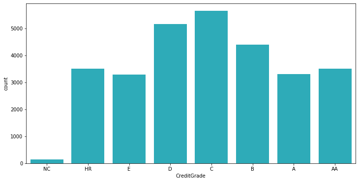

```python
# Creating histogram for CreditGrade, Occupation, EmploymentStatus,
# ProsperRating (Alpha), ListingCategory (numeric) and in the next following boxes
base_color = sns.color_palette()[9]
plt.figure(figsize=(12,6))
sns.countplot(data=df_clean, x='CreditGrade', color=base_color);
```

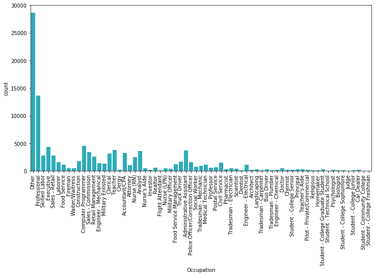

```python
# Occupation Plot
plt.figure(figsize=(12,6))
sns.countplot(data=df_clean, x='Occupation', color=base_color)
plt.xticks(rotation=90);
```

*Comment:* Other is by far the largest category in Occupation which also contains many categories. Unfortunately it makes it not only harder to use the category, but also makes the rest of the population. I might replace other by NaN to make the mapped Occupation a fairer chance.

```python
# Creating a function to change all values of 'Other' into
df_clean['Occupation'] = df_clean['Occupation'].replace('Other', np.nan)
```

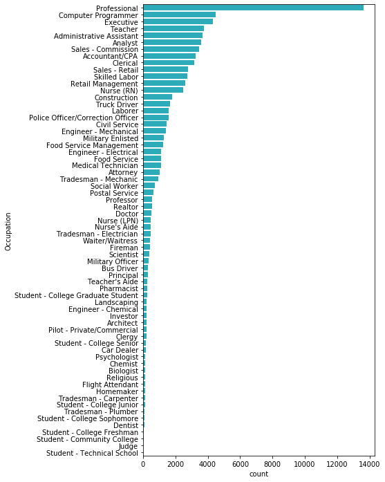

```python
# Now, once more: Occupation Plot and in order
plt.figure(figsize=(6,12))
sns.countplot(data=df_clean, y='Occupation', color=base_color, order = df_clean['Occupation'].value_counts().index);
```

*Comment:* Much better! What I probably will do is choose the top 5 or 10 categories for any relational analysis.

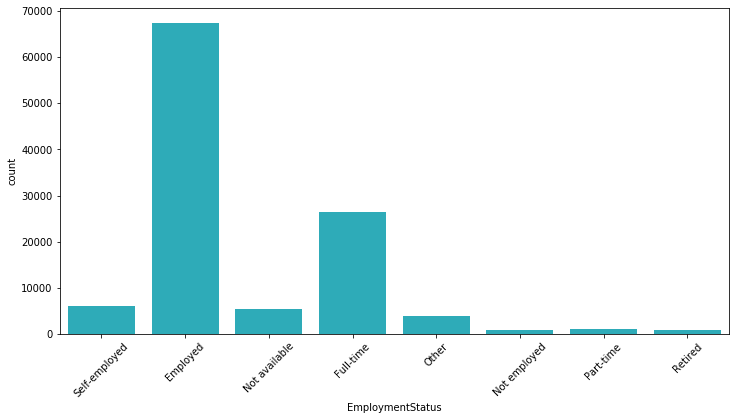

```python
# Employment Status  Plot
plt.figure(figsize=(12,6))
sns.countplot(data=df_clean, x='EmploymentStatus', color=base_color)
plt.xticks(rotation=45);
```

*Comment:* Most people are employed. However, I think that there is a faulty categorisation. Using Full-time and Part-time employment too which is still employed, albeit less granularly detailed. A better categorisation could have been for e.g. self-employed, employed, not employed, retired. Or more detailed, replacing employed with full-time and part-time etc. This means that I have decided that I won't be using this category after further investigation.

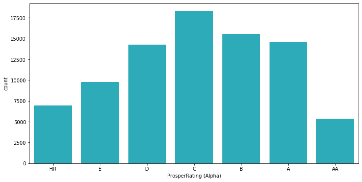

```python
# Prosper Rating (Alpha) Plot
plt.figure(figsize=(12,6))
sns.countplot(data=df_clean, x='ProsperRating (Alpha)', color=base_color);
```

*Comment:* Because Prosper Rating (Alpha and Credit Grade are so similar, I will do a quick comparison to determies if I will use one of them or both.

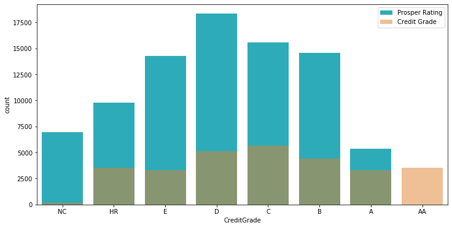

```python
# Prosper Rating (Alpha) Plot and Credit Grade Plot
plt.figure(figsize=(12,6))
sns.countplot(data=df_clean, x='ProsperRating (Alpha)', color=base_color, label='Prosper Rating')
sns.countplot(data=df_clean, x='CreditGrade', color=sns.color_palette()[1], alpha=0.5, label='Credit Grade')
plt.legend();
```

**Comment:** Alright, it is rather clear that credit grade has a lower coverage than prosper rating, thus I will only use prosper rating going forward.

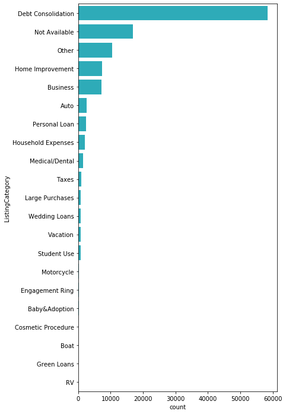

```python
# ListingCategory Plot
plt.figure(figsize=(6,12))
sns.countplot(data=df_clean, y='ListingCategory', color=base_color, order=df_clean['ListingCategory'].value_counts().index);
```

*Comment:* The interesting part is that a large portion of the loans seem to be debt consolidaton, which could indicate that the interest rates are beneficial to the extent that Prosper is preferrable compared to banks and other credit institutions. Not necessarily relevant for this analysis, as we will not compare Prosper with other banks or lender institutions. However, I will probably compare the different top 5 categories with other variables in the dataset.

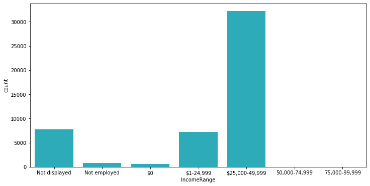

```python
# IncomeRange (numeric) Plot
# First we need to sort the categories according to order
IncomeList = ['Not displayed', 'Not employed', '$0', '$1-24,999', '$25,000-49,999', '50,000-74,999', '75,000-99,999']
IncomeRanList = pd.api.types.CategoricalDtype(ordered = True, categories=IncomeList)
df_clean['IncomeRange'] = df_clean['IncomeRange'].astype(IncomeRanList)
# Then plot the categories
plt.figure(figsize=(12,6))
sns.countplot(data=df_clean, x='IncomeRange', color=base_color);
```

### Section 2: Numerical Exploration

```python
#Just to get an overview of relevant sections for the next part, diving into the numerical variables.
df_clean.head(5)
```

|  | CreditGrade | Term | BorrowerRate | EstimatedLoss | EstimatedReturn | ProsperRating (numeric) | ProsperRating (Alpha) | ProsperScore | ListingCategory | Occupation | EmploymentStatus | EmploymentStatusDuration | CreditScoreRangeLower | CreditScoreRangeUpper | DebtToIncomeRatio | IncomeRange | StatedMonthlyIncome |
| --- | --- | --- | --- | --- | --- | --- | --- | --- | --- | --- | --- | --- | --- | --- | --- | --- | --- |
| 0 | C | 36 | 0.1580 | NaN | NaN | NaN | NaN | NaN | Not Available | NaN | Self-employed | 2.0 | 640.0 | 659.0 | 0.17 | $25,000-49,999 | 3083.333333 |
| 1 | NaN | 36 | 0.0920 | 0.0249 | 0.05470 | 6.0 | A | 7.0 | Home Improvement | Professional | Employed | 44.0 | 680.0 | 699.0 | 0.18 | NaN | 6125.000000 |
| 2 | HR | 36 | 0.2750 | NaN | NaN | NaN | NaN | NaN | Not Available | NaN | Not available | NaN | 480.0 | 499.0 | 0.06 | Not displayed | 2083.333333 |
| 3 | NaN | 36 | 0.0974 | 0.0249 | 0.06000 | 6.0 | A | 9.0 | Motorcycle | Skilled Labor | Employed | 113.0 | 800.0 | 819.0 | 0.15 | $25,000-49,999 | 2875.000000 |
| 4 | NaN | 36 | 0.2085 | 0.0925 | 0.09066 | 3.0 | D | 4.0 | Home Improvement | Executive | Employed | 44.0 | 680.0 | 699.0 | 0.26 | NaN | 9583.333333 |

```
''
```

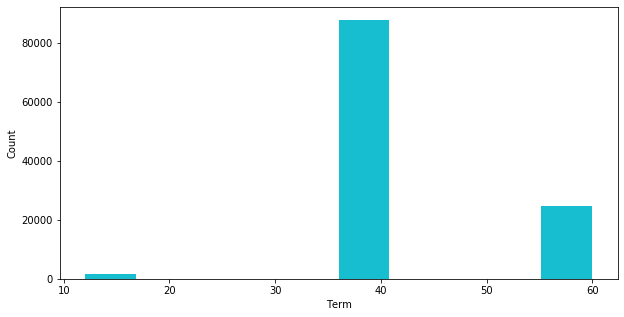

```python
# Histogram / Distribution plots for all the Term column
plt.figure(figsize=(10,5))
plt.hist(df_clean['Term'], color=base_color)
plt.xlabel('Term')
plt.ylabel('Count')
;
```

**Comment:** By the looks of it, I don't see this distribution of three bins as indicitative of helpful for further analysis, the issue is both in size for the three bins and the separation between the buckets are problematic. This column won't be used for more.

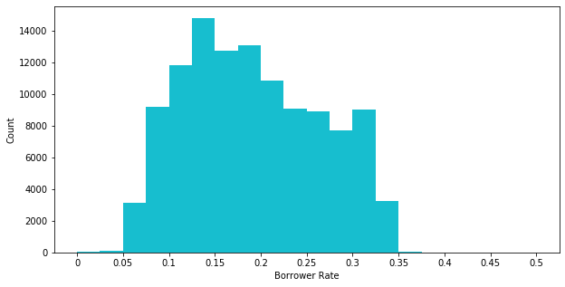

```python
# Plotting histogram for Borrower Rate
plt.figure(figsize=(10,5))
bins_size = np.arange(0, df_clean['BorrowerRate'].max()+0.025,0.025)
plt.hist(df_clean['BorrowerRate'], color=base_color,bins=bins_size)
x_ticks = [0, 0.05, 0.1, 0.15, 0.2, 0.25, 0.3, 0.35, 0.4, 0.45, 0.5]
plt.xticks(x_ticks, x_ticks)
plt.xlabel('Borrower Rate')
plt.ylabel('Count');
```

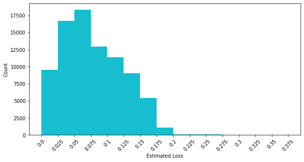

```python
# Plotting histogram for Estimated Loss
plt.figure(figsize=(10,5))
bins_size = np.arange(0, df_clean['EstimatedLoss'].max()+0.025,0.025)
plt.hist(df_clean['EstimatedLoss'], color=base_color,bins=bins_size)
x_ticks = [0.   , 0.025, 0.05 , 0.075, 0.1  , 0.125, 0.15 , 0.175, 0.2,
           0.225, 0.25 , 0.275, 0.3  , 0.325, 0.35 , 0.375]
plt.xticks(x_ticks, x_ticks, rotation=45)
plt.xlabel('Estimated Loss')
plt.ylabel('Count');
```

**Comment:** This histogram, shows that the data is right skevwed where in terms of estimated loss is rather low, which is interesting and good for the company, Prosper. But most importantly it is very good for the lenders. Will be examined further.

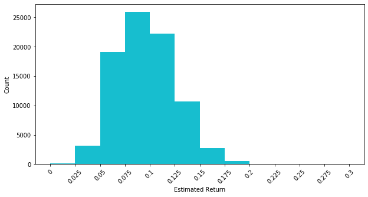

```python
# Plotting histogram for Estimated Return
plt.figure(figsize=(10,5))
bins_size = np.arange(0, df_clean['EstimatedReturn'].max()+0.025,0.025)
plt.hist(df_clean['EstimatedReturn'], color=base_color,bins=bins_size)
x_ticks = [0, 0.025, 0.05, 0.075, 0.1, 0.125, 0.15, 0.175, 0.2,
            0.225, 0.25, 0.275, 0.3]
plt.xticks(x_ticks, x_ticks, rotation=45)
plt.xlabel('Estimated Return')
plt.ylabel('Count');
```

**Comment:** The estimated return seems to be a normal distribution, where most rates of estimated return fall in between 0.075 and 0.125. Interesting to investigate what might correlate with Estimated Loss and Borrower Rate.

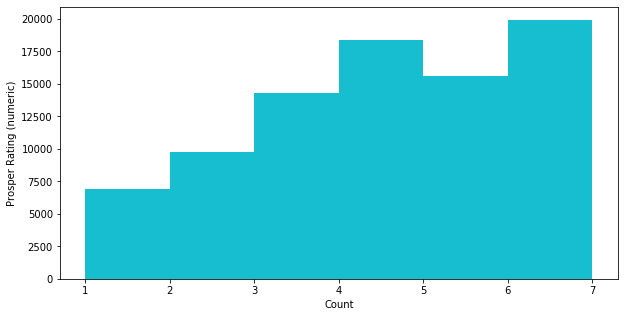

```python
# Plotting Histogram for ProsperRating (numeric)
plt.figure(figsize=(10,5))
bins_size = np.arange(1, df_clean['ProsperRating (numeric)'].max()+1,1)
plt.hist(df_clean['ProsperRating (numeric)'], color=base_color,bins=bins_size)
x_ticks = [1, 2, 3, 4, 5, 6, 7]
plt.xticks(x_ticks, x_ticks)
plt.xlabel('Count')
plt.ylabel('Prosper Rating (numeric)');
```

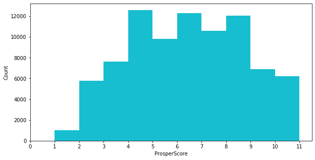

```python
# ProsperScore
# Plotting Histogram for ProsperScore
plt.figure(figsize=(10,5))
bins_size = np.arange(1, df_clean['ProsperScore'].max()+1,1)
plt.hist(df_clean['ProsperScore'], color=base_color,bins=bins_size)
x_ticks = [0, 1, 2, 3, 4, 5, 6, 7, 8, 9, 10, 11]
plt.xticks(x_ticks, x_ticks)
plt.xlabel('ProsperScore')
plt.ylabel('Count');
```

**Comment:** Interesting, there seems to be three peaks in the distribution, this multimodal distribution might have factors the relate to the different peaks.

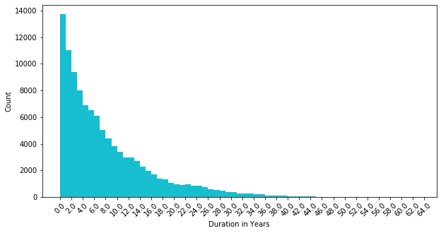

```python
# Plotting a histogram for EmploymentStatusDuration column
plt.figure(figsize=(10,5))
# bin sizes in 12-month intervals since that is the duration of a year
bin_sizes = np.arange(0, df_clean['EmploymentStatusDuration'].max()+12,12)
plt.hist(df_clean['EmploymentStatusDuration'], color=base_color, bins=bin_sizes)
x_ticks = np.arange(0, df_clean['EmploymentStatusDuration'].max()+24,24)
plt.xticks(x_ticks, (x_ticks/12), rotation=45)
plt.xlabel('Duration in Years')
plt.ylabel('Count');
```

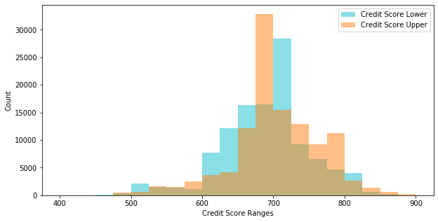

```python
# CreditScoreRangeLower and Upper
plt.figure(figsize=(10,5))
bin_sizes = np.arange(400, df_clean['CreditScoreRangeLower'].max()+25, 25)
plt.hist(df_clean['CreditScoreRangeLower'], color=base_color, bins=bin_sizes, alpha=0.5, label='Credit Score Lower')
plt.hist(df_clean['CreditScoreRangeUpper'], color=sns.color_palette()[1], bins=bin_sizes, alpha=0.5, label='Credit Score Upper')
plt.legend()
plt.xlabel('Credit Score Ranges')
plt.ylabel('Count');
```

**Comment:** Albeit, this plot containing two variables, since they contain a range of an upper and lower credit score, I wanted the distributions to overlap to get an overview of them both but also separately (distinguished by color). This will be a perfect example in the next section for bivariate plots to compare the relationship through a scatterplot. Determining the relationship with lower and upper bounds of credit scores.

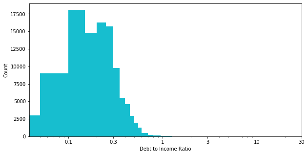

```python
# Plotting a histogram for DebtToIncomeRatio
plt.figure(figsize=(10,5))
bin_sizes = np.arange(0, df_clean['DebtToIncomeRatio'].max()+0.05,0.05)
plt.hist(df_clean['DebtToIncomeRatio'], color=base_color, bins=bin_sizes)
plt.xscale('log')
x_ticks = [0.1, 0.3, 1, 3, 10, 30]
plt.xticks(x_ticks,x_ticks)
plt.ylabel('Count')
plt.xlabel('Debt to Income Ratio');
```

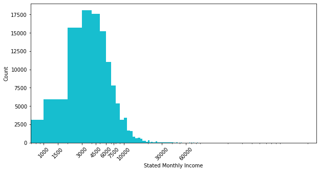

```python
# StatedMonthlyIncome
# Plotting a histogram for StatedMonthlyIncome
plt.figure(figsize=(10,5))
bin_sizes = np.arange(0, df_clean['StatedMonthlyIncome'].max()+1000,1000)
plt.hist(df_clean['StatedMonthlyIncome'], color=base_color, bins=bin_sizes);
plt.xscale('log')
x_ticks = [1000, 1500, 3000, 4500, 6000, 7500, 10000, 30000, 60000]
plt.xticks(x_ticks,x_ticks, rotation=45)
plt.xlabel('Stated Monthly Income')
plt.ylabel('Count');
```

**Comment:** The plot above shows that the distribution for the stated monthly income is right skewed where most people seem to earn about `$`3000-4500 a month. This will be compared to other categorical and numerical variables to determine relationships and correlation.

##### Discuss the distribution(s) of your variable(s) of interest. Were there any unusual points? Did you need to perform any transformations?

The main variables of further investigation are the following columns in the dataset:

Qualitative

- Listing category (top 5)
- Occupation (top 5)
- Prosper Rating (Alpha)

Quantitative

- Borrower Rate
- Estimated Loss
- Estimated Return
- Debt to Income Ratio
- Stated Monthly Income

A few of the categories needed som cleaning and/or tidiness. For example, I swapped the numerical values for the variable with the corresponding values. and then I sorted it after the numerical 0-20 that was originally in the variable.

Both CreditGrade and ProsperRating (alpha) needed to be ordered. However, only ProsperRating will be kept for further analysis. For this I used pd.api.types.CategoricalDtype to order the columns.

DebtToIncomeRatio and StatedMonthlyIncome both needed their scale to be log in order to get a clearer visualisation of their distribution, therefore I will keep it in mind for further exploration.

### Of the features you investigated, were there any unusual distributions? Did you perform any operations on the data to tidy, adjust, or change the form of the data? If so, why did you do this?

```python
df_clean.head()
```

|  | CreditGrade | Term | BorrowerRate | EstimatedLoss | EstimatedReturn | ProsperRating (numeric) | ProsperRating (Alpha) | ProsperScore | ListingCategory | Occupation | EmploymentStatus | EmploymentStatusDuration | CreditScoreRangeLower | CreditScoreRangeUpper | DebtToIncomeRatio | IncomeRange | StatedMonthlyIncome |
| --- | --- | --- | --- | --- | --- | --- | --- | --- | --- | --- | --- | --- | --- | --- | --- | --- | --- |
| 0 | C | 36 | 0.1580 | NaN | NaN | NaN | NaN | NaN | Not Available | NaN | Self-employed | 2.0 | 640.0 | 659.0 | 0.17 | $25,000-49,999 | 3083.333333 |
| 1 | NaN | 36 | 0.0920 | 0.0249 | 0.05470 | 6.0 | A | 7.0 | Home Improvement | Professional | Employed | 44.0 | 680.0 | 699.0 | 0.18 | NaN | 6125.000000 |
| 2 | HR | 36 | 0.2750 | NaN | NaN | NaN | NaN | NaN | Not Available | NaN | Not available | NaN | 480.0 | 499.0 | 0.06 | Not displayed | 2083.333333 |
| 3 | NaN | 36 | 0.0974 | 0.0249 | 0.06000 | 6.0 | A | 9.0 | Motorcycle | Skilled Labor | Employed | 113.0 | 800.0 | 819.0 | 0.15 | $25,000-49,999 | 2875.000000 |
| 4 | NaN | 36 | 0.2085 | 0.0925 | 0.09066 | 3.0 | D | 4.0 | Home Improvement | Executive | Employed | 44.0 | 680.0 | 699.0 | 0.26 | NaN | 9583.333333 |

```python
# Before the next section,
# I will select to proceed with a new dataframe only containing the variables declared in the previous section.
new_sel_col = [
                'ListingCategory', 'Occupation', 'BorrowerRate',
                'EstimatedLoss', 'EstimatedReturn', 'ProsperRating (Alpha)',
                'StatedMonthlyIncome', 'DebtToIncomeRatio'
              ]
df_clean_two = df_clean[new_sel_col]
df_clean_two.head()
```

|  | ListingCategory | Occupation | BorrowerRate | EstimatedLoss | EstimatedReturn | ProsperRating (Alpha) | StatedMonthlyIncome | DebtToIncomeRatio |
| --- | --- | --- | --- | --- | --- | --- | --- | --- |
| 0 | Not Available | NaN | 0.1580 | NaN | NaN | NaN | 3083.333333 | 0.17 |
| 1 | Home Improvement | Professional | 0.0920 | 0.0249 | 0.05470 | A | 6125.000000 | 0.18 |
| 2 | Not Available | NaN | 0.2750 | NaN | NaN | NaN | 2083.333333 | 0.06 |
| 3 | Motorcycle | Skilled Labor | 0.0974 | 0.0249 | 0.06000 | A | 2875.000000 | 0.15 |
| 4 | Home Improvement | Executive | 0.2085 | 0.0925 | 0.09066 | D | 9583.333333 | 0.26 |

```python
df_test = df_clean_two[df_clean_two['ProsperRating (Alpha)'] == df_clean_two['ProsperRating (Alpha)']]
df_test
```

|  | ListingCategory | Occupation | BorrowerRate | EstimatedLoss | EstimatedReturn | ProsperRating (Alpha) | StatedMonthlyIncome | DebtToIncomeRatio |
| --- | --- | --- | --- | --- | --- | --- | --- | --- |
| 1 | Home Improvement | Professional | 0.0920 | 0.0249 | 0.05470 | A | 6125.000000 | 0.18 |
| 3 | Motorcycle | Skilled Labor | 0.0974 | 0.0249 | 0.06000 | A | 2875.000000 | 0.15 |
| 4 | Home Improvement | Executive | 0.2085 | 0.0925 | 0.09066 | D | 9583.333333 | 0.26 |
| 5 | Debt Consolidation | Professional | 0.1314 | 0.0449 | 0.07077 | B | 8333.333333 | 0.36 |
| 6 | Debt Consolidation | Sales - Retail | 0.2712 | 0.1275 | 0.11070 | E | 2083.333333 | 0.27 |
| ... | ... | ... | ... | ... | ... | ... | ... | ... |
| 113932 | Debt Consolidation | Food Service Management | 0.1864 | 0.0699 | 0.09500 | C | 4333.333333 | 0.13 |
| 113933 | Other | Professional | 0.1110 | 0.0200 | 0.08070 | A | 8041.666667 | 0.11 |
| 113934 | Debt Consolidation | NaN | 0.2150 | 0.1025 | 0.08578 | D | 2875.000000 | 0.51 |
| 113935 | Home Improvement | Food Service | 0.2605 | 0.0850 | 0.15950 | C | 3875.000000 | 0.48 |
| 113936 | Debt Consolidation | Professor | 0.1039 | 0.0299 | 0.06081 | A | 4583.333333 | 0.23 |

84853 rows × 8 columns

## Bivariate Exploration

> In this section, investigate relationships between pairs of variables in your data. Make sure the variables that you cover here have been introduced in some fashion in the previous section (univariate exploration).

### Comment:

In this section, The three categorical variables : ProsperRating (Alpha), ListingCategory (top five categories), and Occupation (top 5 categories) will be investigated in relation to EstimatedLoss, EstimatedReturn, BorrowerRate, DebtToIncomeRatio, and StatedMonthlyIncome.

That means that the categorical vs quantitative comparisons will need 15 plots alone. Then Borrower Rate will be compared with EstimatedLoss, EstimatedReturn, DebtToIncomeRatio, and StatedMonthlyIncome in a quantitative vs quantitative approach, which adds 4 more plots, totaling in a number of 19 plots for the bivariate analysis section. After that I will have to limit the last part down to a maximum of 5-7 Plots for the multivariate analysis in order to keep things organised and divide this chapter in particular into spearate parts for readability in general.

#### ProsperRating (Alpha) Exploration

In this section we'll explore ProsperRating (Alpha)

```python
df_clean_two['ListingCategory'].value_counts()
```

```
Debt Consolidation    58308
Not Available         16965
Other                 10494
Home Improvement       7433
Business               7189
Auto                   2572
Personal Loan          2395
Household Expenses     1996
Medical/Dental         1522
Taxes                   885
Large Purchases         876
Wedding Loans           771
Vacation                768
Student Use             756
Motorcycle              304
Engagement Ring         217
Baby&Adoption           199
Cosmetic Procedure       91
Boat                     85
Green Loans              59
RV                       52
Name: ListingCategory, dtype: int64
```

```python
# Creating new dataframes with only the top 5 categories for Occupation and ListingCategory
df_occupation_top5 = df_clean_two[(df_clean_two['Occupation'] == "Professional")|(df_clean_two['Occupation'] == "Computer Programmer")|(df_clean_two['Occupation'] == "Executive")|(df_clean_two['Occupation'] == "Teacher")|(df_clean_two['Occupation'] == "Administrative Assistant")]
# I chose to ot include 'Not Available' since it is the same as NaN
df_listing_top5 = df_clean_two[(df_clean_two['ListingCategory'] == "Debt Consolidation")|(df_clean_two['ListingCategory'] == "Other")|(df_clean_two['ListingCategory'] == "Home Improvement")|(df_clean_two['ListingCategory'] == "Business")|(df_clean_two['ListingCategory'] == "Auto")]
```

```python
"""
    Noticed that a lot of categories were kept as 0 using value_counts,
    most likely because of my function that was created to sort the categories created according to the list.
    So I found a resource: https://github.com/pandas-dev/pandas/issues/8559
    documentation here: https://pandas.pydata.org/pandas-docs/stable/reference/api/pandas.Series.cat.remove_categories.html#pandas.Series.cat.remove_categories
    Which helped me to keep only the selected 5 categories that had the highest count.
"""

df_listing_top5.ListingCategory.cat.remove_unused_categories(inplace=True)
```

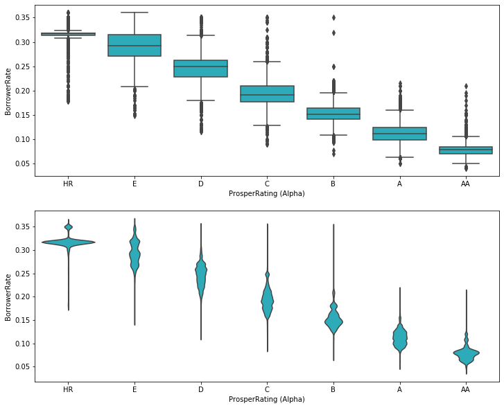

```python
# Box plot and violinplot exploring the relationship between ProsperRating (Alpha) and BorrowerRate
plt.figure(figsize=(12,10))
plt.subplot(2,1,1)
sns.boxplot(data=df_clean_two, x='ProsperRating (Alpha)', y='BorrowerRate', color=base_color)
plt.subplot(2,1,2)
sns.violinplot(data=df_clean_two, x='ProsperRating (Alpha)', y='BorrowerRate', color=base_color, inner=None);
```

**Comment:** It is interesting that as the ProsperRating (Alpha) increases in rating, the BorrowerRate seems to decrease, and the patterns gets clearer towards the categorical extremes, the distribution gets clearer; especially, when looking at the violin plot that shows the distribution of each category.

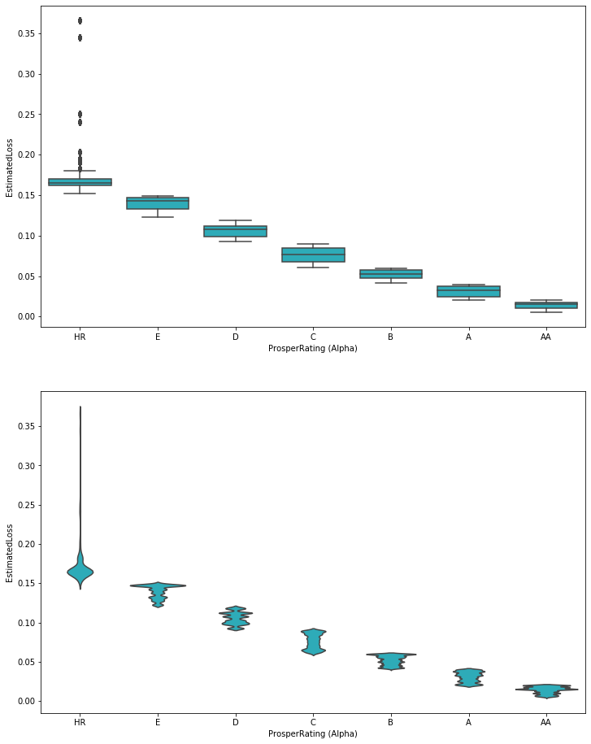

```python
# Box plot and violinplot exploring the relationship between ProsperRating (Alpha) and EstimatedLoss
plt.figure(figsize=(12,16))
plt.subplot(2,1,1)
sns.boxplot(data=df_clean_two, x='ProsperRating (Alpha)', y='EstimatedLoss', color=base_color)
#plt.yscale('log')
plt.subplot(2,1,2)
sns.violinplot(data=df_clean_two, x='ProsperRating (Alpha)', y='EstimatedLoss', color=base_color, inner=None);
#plt.yscale('log')
```

**Comment:** Not the prettiest plots, however, rather indicative. Low inter-quartile range and clearly declining Estimated Loss for each category, each better rating decreases the estimated loss for the borrower.

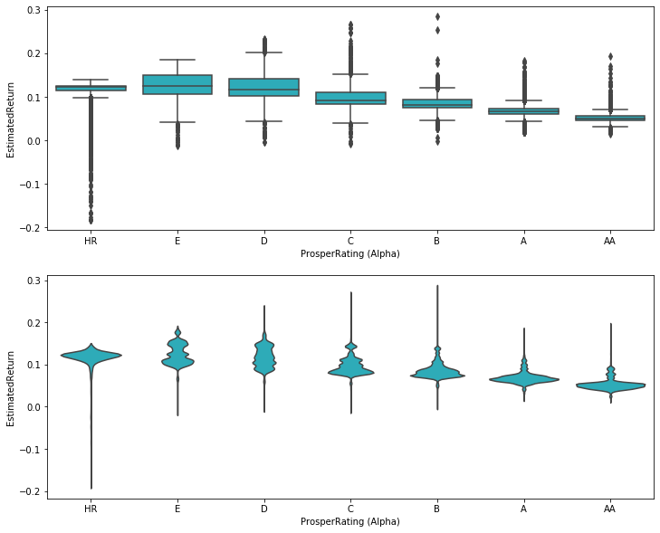

```python
# Box plot and violinplot exploring the relationship between ProsperRating (Alpha) and EstimatedReturn
plt.figure(figsize=(12,10))
plt.subplot(2,1,1)
sns.boxplot(data=df_clean_two, x='ProsperRating (Alpha)', y='EstimatedReturn', color=base_color)
#plt.yscale('log')
plt.subplot(2,1,2)
sns.violinplot(data=df_clean_two, x='ProsperRating (Alpha)', y='EstimatedReturn', color=base_color, inner=None)
#plt.yscale('log');
```

**Comment:** Better looking plots, not pretty tho, but it does the job. The estimated return is higher for Prosper Rating E, and declines for each incremental more secure category. Probably because the previous plots regarding borrower rate and estimated loss. Less interest rate paid if you have a better rating, and lower risk of loss; thus, the estimated return is lower for each incremental rating.

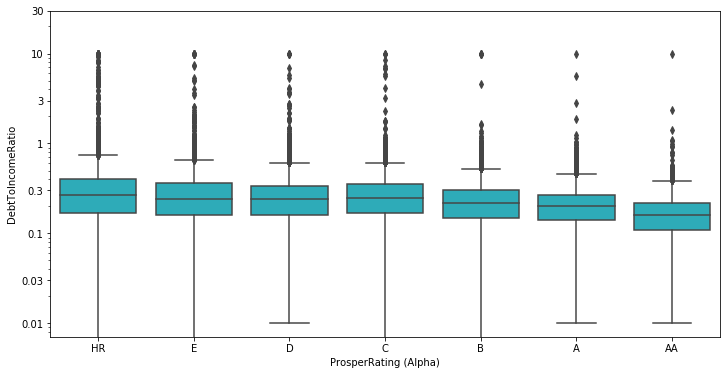

```python
# Box plot and violinplot exploring the relationship between ProsperRating (Alpha) and DebtToIncomeRatio
plt.figure(figsize=(12,6))
sns.boxplot(data=df_clean_two, x='ProsperRating (Alpha)', y='DebtToIncomeRatio', color=base_color)
plt.yscale('log')
y_ticks = [0.01, 0.03, 0.1, 0.3, 1, 3, 10, 30]
plt.yticks(y_ticks,y_ticks);
```

**Comment:** It seems like for each incremental category in prosper rating, the debt-to-income ratio is slowly decreasing. Much like estimated loss, borrower rate, and estimated return.

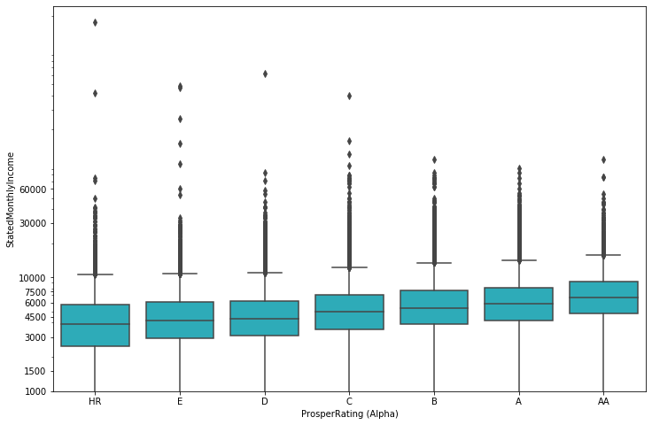

```python
# Box plot exploring the relationship between ProsperRating (Alpha) and StatedMonthlyIncome
plt.figure(figsize=(12,8))
sns.boxplot(data=df_clean_two, x='ProsperRating (Alpha)', y='StatedMonthlyIncome', color=base_color)
plt.yscale('log')
y_ticks = [1000, 1500, 3000, 4500, 6000, 7500, 10000, 30000, 60000]
plt.yticks(y_ticks,y_ticks);
```

**Comment:** Indeed, an increase in income is related to recieving a superior credit grade. Thus, it is not strange to assume that perhaps the amount of debt is correlated to Stated Income / Prosper Rating.

#### Listing Category Exploration

In this section we'll explore ListingCategory

```python
df_listing_top5.head()
```

|  | ListingCategory | Occupation | BorrowerRate | EstimatedLoss | EstimatedReturn | ProsperRating (Alpha) | StatedMonthlyIncome | DebtToIncomeRatio |
| --- | --- | --- | --- | --- | --- | --- | --- | --- |
| 1 | Home Improvement | Professional | 0.0920 | 0.0249 | 0.05470 | A | 6125.000000 | 0.18 |
| 4 | Home Improvement | Executive | 0.2085 | 0.0925 | 0.09066 | D | 9583.333333 | 0.26 |
| 5 | Debt Consolidation | Professional | 0.1314 | 0.0449 | 0.07077 | B | 8333.333333 | 0.36 |
| 6 | Debt Consolidation | Sales - Retail | 0.2712 | 0.1275 | 0.11070 | E | 2083.333333 | 0.27 |
| 7 | Home Improvement | Laborer | 0.2019 | 0.0799 | 0.09840 | C | 3355.750000 | 0.24 |

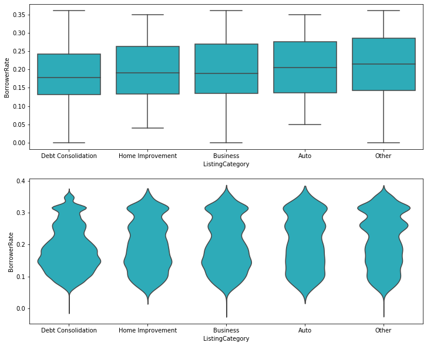

```python
# Box plot and violinplot exploring the relationship between ListingCategory and BorrowerRate
plt.figure(figsize=(12,10))
plt.subplot(2,1,1)
sns.boxplot(data=df_listing_top5, x='ListingCategory', y='BorrowerRate', color=base_color)
plt.subplot(2,1,2)
sns.violinplot(data=df_listing_top5, x='ListingCategory', y='BorrowerRate', color=base_color, inner=None);
```

**Comment:** Here, specificity does seem to matter. Where the borrower rate is more favourable based on which category the borrower has stated the intention of the loan. The best categories according to the plot thats associated with good rates are Debt Consolidationm, Home Improvement and Business. This might be due to the security associated with for e.g. CreditGrades or Income. This would have to be investigated further to actually know. However, I wonder if the insight is really what I want to investigate further.

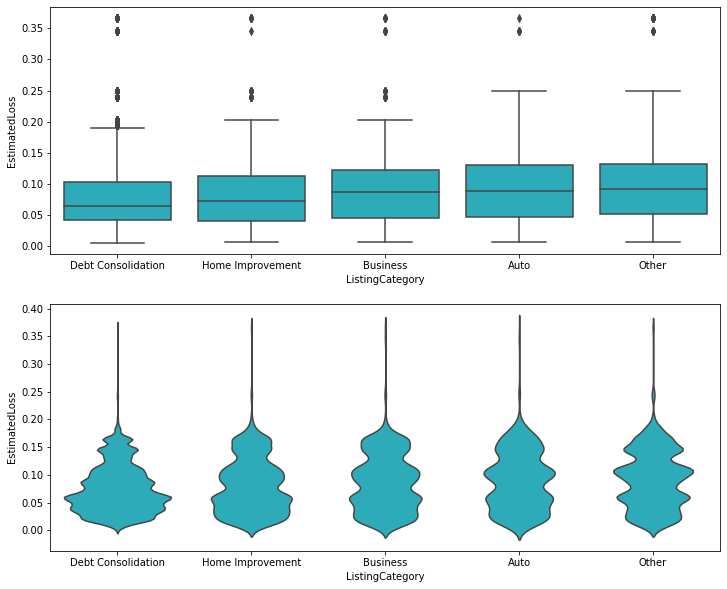

```python
# Box plot and violinplot exploring the relationship between ListingCategory and EstimatedLoss
plt.figure(figsize=(12,10))
plt.subplot(2,1,1)
sns.boxplot(data=df_listing_top5, x='ListingCategory', y='EstimatedLoss', color=base_color)
plt.subplot(2,1,2)
sns.violinplot(data=df_listing_top5, x='ListingCategory', y='EstimatedLoss', color=base_color, inner=None);
```

**Comment:** It seems like the estimated loss is the lowest at debt consolidation, when comparing to the other top 5 listing categories. In comparison to the previous plot, where we saw Home Improvement, Debt Consolidation, and Business had the best interest rates.

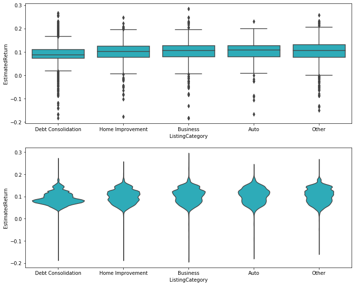

```python
# Box plot and violinplot exploring the relationship between ListingCategory and EstimatedReturn
plt.figure(figsize=(12,10))
plt.subplot(2,1,1)
sns.boxplot(data=df_listing_top5, x='ListingCategory', y='EstimatedReturn', color=base_color)
plt.subplot(2,1,2)
sns.violinplot(data=df_listing_top5, x='ListingCategory', y='EstimatedReturn', color=base_color, inner=None);
```

**Comment:** Now it makes sense, the likelihood of estimated return is lower than the other categories, but since it has a lower probability of being high in estimated loss it seems like a classic low risk- low reward scenario. In terms of loans, boring can be very good.

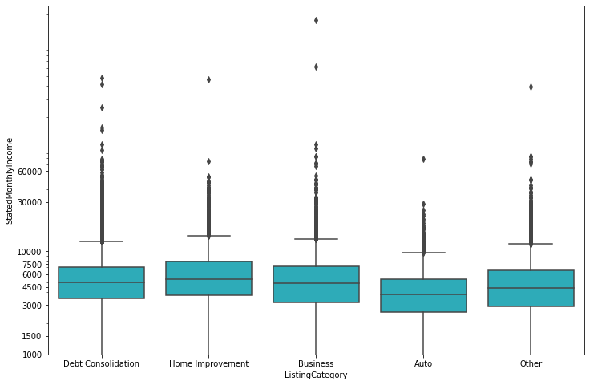

```python
# Box plot exploring the relationship between ListingCategory and EstimatedReturn
plt.figure(figsize=(12,8))
sns.boxplot(data=df_listing_top5, x='ListingCategory', y='StatedMonthlyIncome', color=base_color)
plt.yscale('log')
y_ticks = [1000, 1500, 3000, 4500, 6000, 7500, 10000, 30000, 60000]
plt.yticks(y_ticks,y_ticks);
```

**Comment:** Lower income ranges seem to take more loans for automobiles, while the mid-range incomes take more loans for business ventures, home improvement, and debt consolidation.

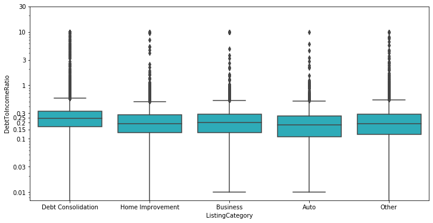

```python
# Box plot exploring the relationship between ListingCategory and DebtToIncomeRatio
plt.figure(figsize=(12,6))
sns.boxplot(data=df_listing_top5, x='ListingCategory', y='DebtToIncomeRatio', color=base_color)
plt.yscale('log')
y_ticks = [0.01, 0.03, 0.1, 0.15, 0.2, 0.25, 0.3, 1, 3, 10, 30]
plt.yticks(y_ticks,y_ticks);
```

**Comment:** Here, the only category that has a small difference in debt to income ratio is debt consolidation, where the cateogry seems to be a fraction more indebted.

#### Occupation Exploration

In this section we'll explore Occupation

```python
df_occupation_top5.head()
```

|  | ListingCategory | Occupation | BorrowerRate | EstimatedLoss | EstimatedReturn | ProsperRating (Alpha) | StatedMonthlyIncome | DebtToIncomeRatio |
| --- | --- | --- | --- | --- | --- | --- | --- | --- |
| 1 | Home Improvement | Professional | 0.0920 | 0.0249 | 0.05470 | A | 6125.000000 | 0.18 |
| 4 | Home Improvement | Executive | 0.2085 | 0.0925 | 0.09066 | D | 9583.333333 | 0.26 |
| 5 | Debt Consolidation | Professional | 0.1314 | 0.0449 | 0.07077 | B | 8333.333333 | 0.36 |
| 14 | Debt Consolidation | Computer Programmer | 0.0949 | 0.0224 | 0.06030 | A | 10833.333333 | 0.20 |
| 16 | Auto | Professional | 0.2809 | 0.1225 | 0.12480 | E | 8291.666667 | 0.15 |

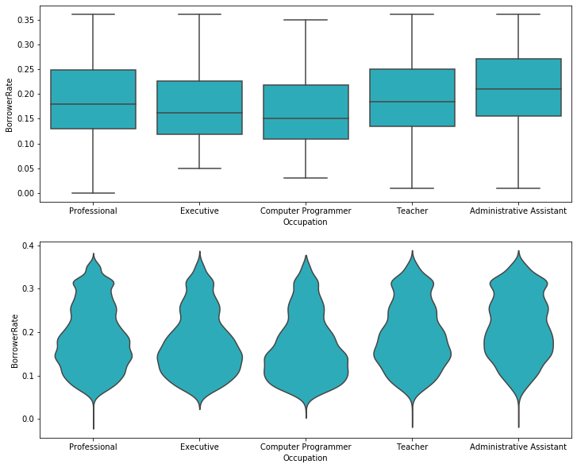

```python
# Box plot and violinplot exploring the relationship between ListingCategory and BorrowerRate
plt.figure(figsize=(12,10))
plt.subplot(2,1,1)
sns.boxplot(data=df_occupation_top5, x='Occupation', y='BorrowerRate', color=base_color)
plt.subplot(2,1,2)
sns.violinplot(data=df_occupation_top5, x='Occupation', y='BorrowerRate', color=base_color, inner=None);
```

**Comment:** The list of most beneficial jobs (top 5 most popular) in relation to borrower rate are the following:

1. Computer programmer
2. Executive
3. Proffessional
4. Teacher
5. Administrative Assistant

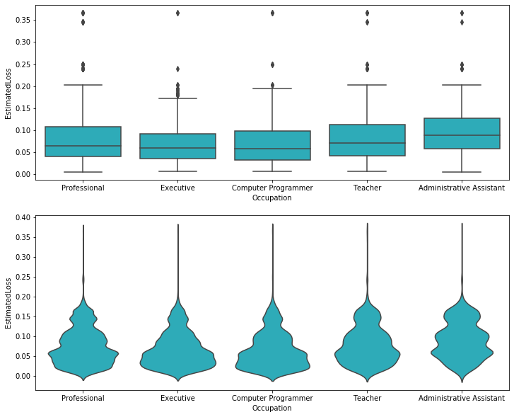

```python
# Box plot and violinplot exploring the relationship between ListingCategory and EstimatedLoss
plt.figure(figsize=(12,10))
plt.subplot(2,1,1)
sns.boxplot(data=df_occupation_top5, x='Occupation', y='EstimatedLoss', color=base_color)
plt.subplot(2,1,2)
sns.violinplot(data=df_occupation_top5, x='Occupation', y='EstimatedLoss', color=base_color, inner=None);
```

**Comment:** Estimated loss seems to be the lowest for Executive and Computer Programmer, almost identical, then Professional and Teacher that are also very similar

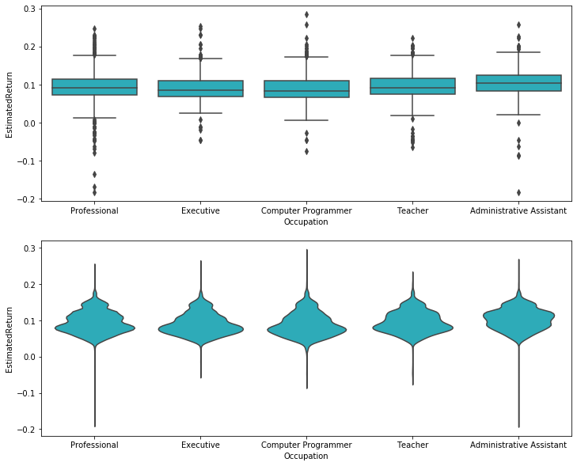

```python
# Box plot and violinplot exploring the relationship between ListingCategory and EstimatedReturn
plt.figure(figsize=(12,10))
plt.subplot(2,1,1)
sns.boxplot(data=df_occupation_top5, x='Occupation', y='EstimatedReturn', color=base_color)
plt.subplot(2,1,2)
sns.violinplot(data=df_occupation_top5, x='Occupation', y='EstimatedReturn', color=base_color, inner=None);
```

**Comment:** The EstimatedReturn for professionals, executives and computer programmers is less than for teachers and administrative assistant. Rather intuitive since those three professions give better borrower rates and have a lower risk of estimated loss.

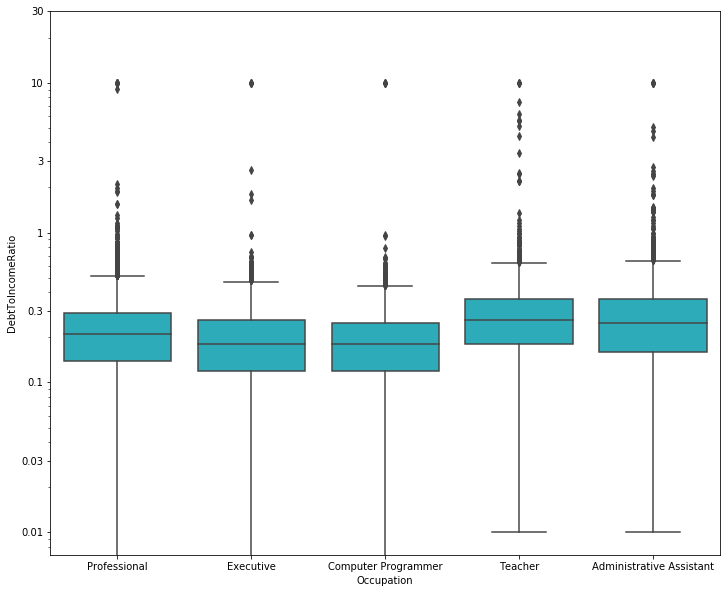

```python
# Box plot and violinplot exploring the relationship between ListingCategory and DebtToIncomeRatio
plt.figure(figsize=(12,10))
sns.boxplot(data=df_occupation_top5, x='Occupation', y='DebtToIncomeRatio', color=base_color)
plt.yscale('log')
y_ticks = [0.01, 0.03, 0.1, 0.3, 1, 3, 10, 30]
plt.yticks(y_ticks,y_ticks);
```

**Comment:** In conjunction with lower rates, loss, return, and Professional, Executive and Computer Programmer all have lower DebtToIncomeRatio.

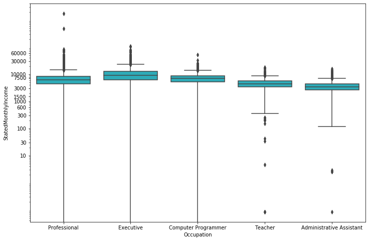

```python
# Box plot and violinplot exploring the relationship between ListingCategory and StatedMonthlyIncome
plt.figure(figsize=(12,8))
sns.boxplot(data=df_occupation_top5, x='Occupation', y='StatedMonthlyIncome', color=base_color)
plt.yscale('log')
y_ticks = [10, 30, 100, 300, 600, 1000, 1500, 3000, 7500, 10000, 30000, 60000]
plt.yticks(y_ticks,y_ticks);
```

**Comment:** Professional, Executive and Computer Programmer are getting the most in monthly income, while Teacher and Administrative Assistant earn less.

#### Quant - Quant Exploration

In this section we'll explore Quantitative against Quantitative values, using BorrowerRate as the dependent variable, where the independent variables we're using to measure the effect are:

- Estimated Loss
- Estimated Return
- Debt to Income Ratio
- Stated Monthly Income

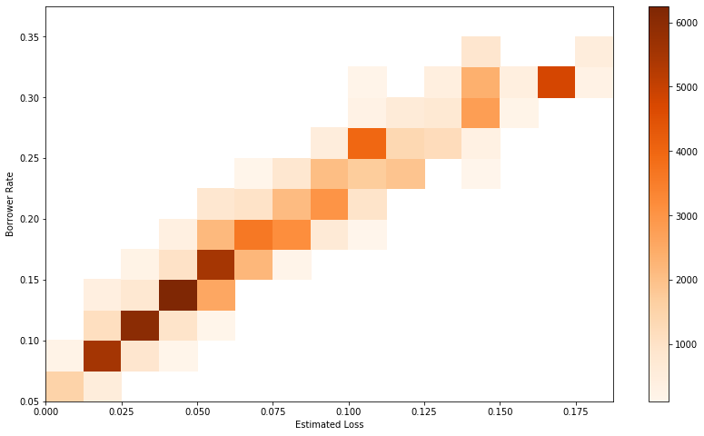

```python
# Heatmap comparing the relationship between BorrowerRate and Estimated Loss
plt.figure(figsize=(14,8))
bins_x = np.arange(0,0.175+0.025,0.0125)
bins_y = np.arange(0.05,0.35+0.05,0.025)
plt.hist2d(data=df_clean_two, x='EstimatedLoss', y='BorrowerRate', bins= [bins_x, bins_y], cmap='Oranges', cmin=100)
plt.xlabel('Estimated Loss')
plt.ylabel('Borrower Rate')
plt.colorbar();
```

**Comment:** Plotting a scatter plot provided messy readings with overfitted data, however, a 2-d histogram solved that, where we can se plotted data into bins. In the plot above, we can se a clear relationship as tht estimated loss increases, so does the Borrower rate follow suit.

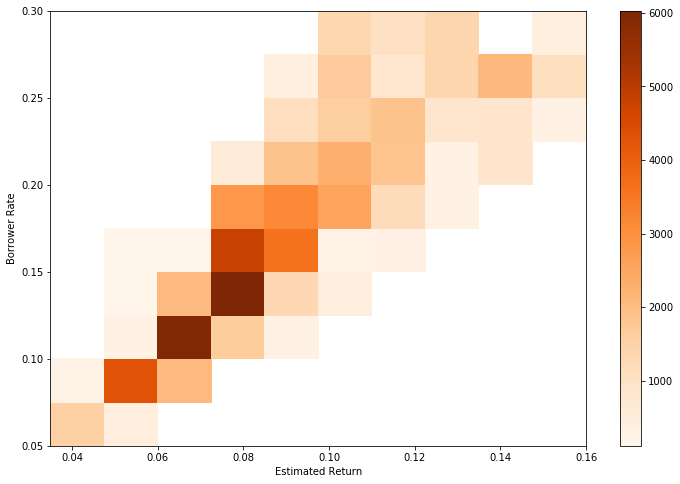

```python
# Heatmap comparing the relationship between BorrowerRate and Estimated Return
plt.figure(figsize=(12,8))
bins_x = np.arange(0.035, 0.16+0.0125, 0.0125)
bins_y = np.arange(0.05, 0.3+0.025, 0.025)
plt.hist2d(data=df_clean_two, x='EstimatedReturn', y='BorrowerRate', bins= [bins_x, bins_y], cmap='Oranges', cmin=100)
plt.colorbar()
plt.xlabel('Estimated Return')
plt.ylabel('Borrower Rate');
```

**Comment:** Here, we can see a similar relationship as previous plot displayed. As the Estimated Return increases, so does the Borrower Rate.

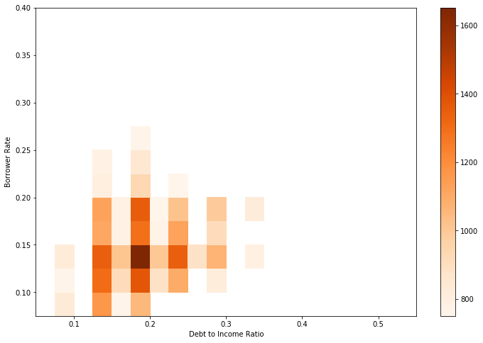

```python
# Scatterplot comparing the relationship between BorrowerRate and Debt to Income Ratio
plt.figure(figsize=(12,8))
bins_x = np.arange(0.05, 0.55+0.025, 0.025)
bins_y = np.arange(0.075, 0.4+0.025,0.025)
plt.hist2d(data=df_clean_two, x='DebtToIncomeRatio', y='BorrowerRate', bins=[bins_x, bins_y], cmap='Oranges', cmin=750)
plt.colorbar()
plt.xlabel('Debt to Income Ratio')
plt.ylabel('Borrower Rate');
```

**Comment:** Although the relationship is a lot weaker than previous plots, There is a small correlation between increased Debt to Incoe Ratio and increased Borrower Rate.

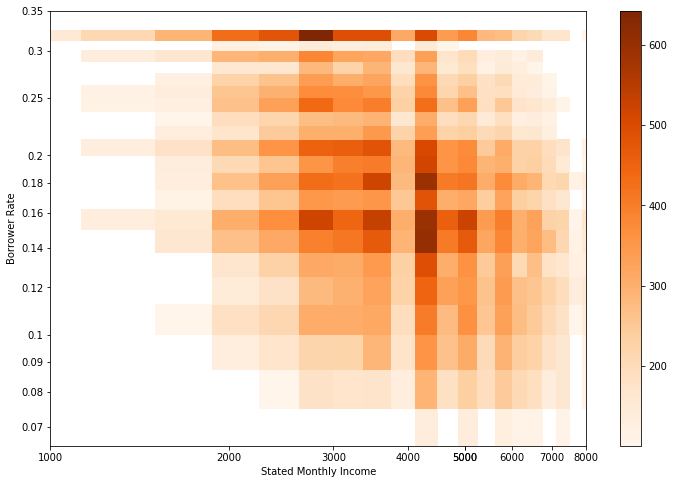

```python
# Scatterplot comparing the relationship between BorrowerRate and Stated Motnhly Income
plt.figure(figsize=(12,8))
bins_y = np.arange(0.05, 0.35+0.0125, 0.0125)
bins_x = np.arange(1, 8000+375, 375)
plt.hist2d(data=df_clean_two, y='BorrowerRate', x='StatedMonthlyIncome', bins=[bins_x, bins_y], cmap='Oranges',cmin=100)
plt.xscale('log')
plt.yscale('log')
x_ticks = [1000, 2000, 3000, 4000, 5000, 5000, 6000, 7000, 8000]
y_ticks = [0.05, 0.06, 0.07, 0.08, 0.09, 0.1, 0.12, 0.14, 0.16, 0.18, 0.2, 0.25, 0.3, 0.35]
plt.xticks(x_ticks, x_ticks)
plt.yticks(y_ticks, y_ticks)
plt.xlim(1000, 8000)
plt.ylim(0.065, 0.35)
#plt.yscale('log')
plt.colorbar()
plt.xlabel('Stated Monthly Income')
plt.ylabel('Borrower Rate');
```

**Comment:** A weak relationship; however, a small negative trend following the increasing Stated Monthly Income correlating with a decreasing Borrower Rate.

### Talk about some of the relationships you observed in this part of the investigation. How did the feature(s) of interest vary with other features in the dataset?

I think that one really interesting feature about the dataset is the relation Prosper Rating has with the different quantitative relationships, especially, Borrower Rate, Estimated Loss, and Estimated Return. Which Will be invesitaged further.

Also, I want to see a correlation matrix between Borrower Rate, Estimated Return and Monthly Stated Income.

### Did you observe any interesting relationships between the other features (not the main feature(s) of interest)?

I was a bit surprised that the Stated monthly income did not have as distinct relationship to lower Borrower Rates, in a similar fashion I also assumed the the Debt to Income Ratio would affect the Borrower rate as well.

## Multivariate Exploration

> Create plots of three or more variables to investigate your data even further. Make sure that your investigations are justified, and follow from your work in the previous sections.

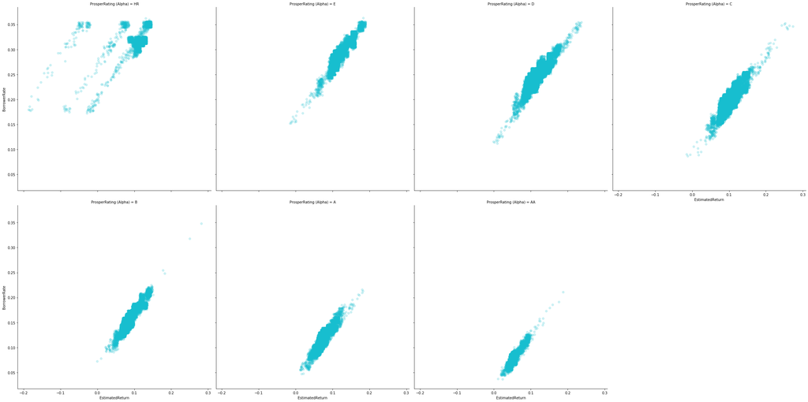

```python
# FacetGrid Plots to examine the relatinship between Borrower Rate, Estimated Return and Prosper Rating
g = sns.FacetGrid(data = df_clean_two, col='ProsperRating (Alpha)', size=8, col_wrap = 4, margin_titles=True)
g.map(sns.regplot, 'EstimatedReturn', 'BorrowerRate', y_jitter=0.00625, x_jitter=0.00625, fit_reg=False, scatter_kws = {'alpha': 1/5}, color=base_color);
```

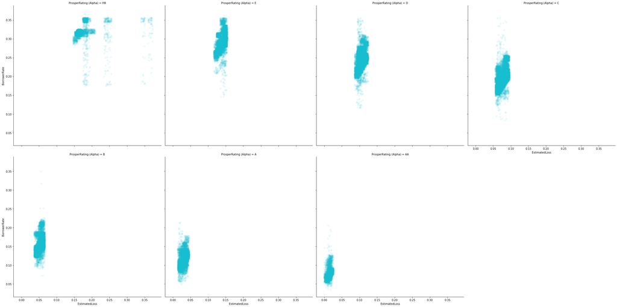

```python
# FacetGrid Plots to examine the relatinship between BorrowerRate, EstimatedReturn, and ProsperRating (Alpha)
g = sns.FacetGrid(data = df_clean_two, col='ProsperRating (Alpha)', size=8, col_wrap = 4, margin_titles=True)
g.map(sns.regplot, 'EstimatedLoss', 'BorrowerRate', y_jitter=0.00625, x_jitter=0.00625, scatter_kws={'alpha':1/15} , fit_reg=False, color=base_color);
```

**Comment:** It is rather evident that the lower the rating, the higher the Estimated Loss and the Borrower Rate. For each category in ProsperRating, the Estimated Loss decreases and so does the Borrower Rate.

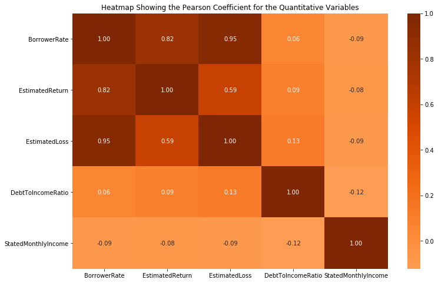

```python
# Correlational Matrices between Borrower Rate, Estimated Return and Stated Monthly Income
plt.figure(figsize=(12,8))
plt.title('Heatmap Showing the Pearson Coefficient for the Quantitative Variables')
sns.heatmap(df_clean_two[['BorrowerRate', 'EstimatedReturn', 'EstimatedLoss', 'DebtToIncomeRatio','StatedMonthlyIncome']].corr(), annot=True, fmt='.2f', cmap='Oranges', center=0);
```

**Comment:** Interestingly the variables that have the strongest correlation are Borrower Rate with Estimated Loss, Borrower Rate and Estimated Return, and then a moderate correlation between Estimated Loss and Estimated Return. It seems like the number one priority for prosper is to determine the loss, then set an appropriate borrower rate.

## Results

I think that the biggest take away is that Estimated Loss may hugely affect which Prosper Rating a borrower recieves, which obviously then affects the Borrower Rate. Initially, I thought that the Estimated Return would have had the strongest correlation than it showed, but most surprising is the low effect of Stated Monthly Income on Borrower Rate. I assumed that the income would affect the rate more. Obviously there might have been more variables looked at, and from the 80 columns there could have been extensive research as to why and how variables relate to each other. It would have been interesting research more layers of qualitative and quantitative variables. However, I am satisfied that it seems Like Estimated Loss and Estimatet Return are key takeaways from my this gleer at Prospers Data.

## Resources

List of resources:

- [Implementing a boolean search for multiple columns](https://stackoverflow.com/questions/22546425/how-to-implement-a-boolean-search-with-multiple-columns-in-pandas)
- [Getting rid of extranous 0 value categories in column](https://github.com/pandas-dev/pandas/issues/8559)
- [Series `cat.remove_categories`, dropping unused categories](https://pandas.pydata.org/pandas-docs/stable/reference/api/pandas.Series.cat.remove_categories.html#pandas.Series.cat.remove_categories)
- [Using a function with if/elif/else statements to determine the value for the ListingCategory column](https://knowledge.udacity.com/questions/80210)
- [FacetGrid, Heatmap, and PairGrid examples were taken from the Udacity classroom](https://classroom.udacity.com/)